# frazer_gad_assessment

November 19, 2020

## Request

For each line, the first column represents the time the measurement was made, the second column represents the id of the patient submitting the assessment, the third column is the type of assessment submitted, the fourth column is the date that the patient was created, and the fifth column represents the final score of the assessment.

Given the information you have and any light research you'd like to do on the topic, what insights can you draw? What assumptions have you made about the data? What are 2-3 additional pieces of information that would be important to collect? We are not looking for production-ready code, but we will assess both your approach to visualization and your technical abilities.

## Contents

start: 11/19: 9:42AM finish code part: 11/19: 11:28AM sql effort: 25 min

## Answering questions

Q:Given the information you have and any light research you'd like to do on the topic, what insights can you draw?

Likely can make the argument that this group has improved over time

Q:What assumptions have you made about the data? Lots: that it's clean– no obvious errors of user input or data quality; that it's complete– that patients have all tests included for a given time period andd that time period is a relevan timme period. I might also guess that some treatment has happened, but it would be good to know if this is a control or treatment sample- have these patients had any intervention?

Q:What are 2-3additional pieces of information that would be important to collect? Baseline expectations (both about the survey audience– is this a population sample– and treatment if any) and typical outcomes could help set up the evaluation of these data. Where does this data come from? Is the patient group homogenous?

## Patient outcomes are positive for severe cases

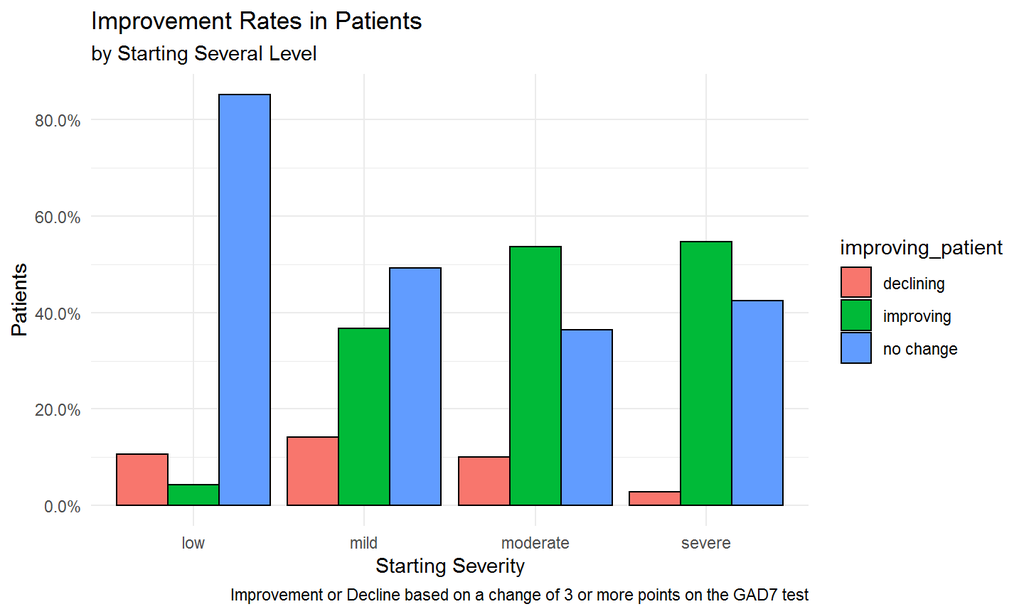

## SQL answers

Note; these are written blind, so it's possible that syntax errors exist. they assume clean tables, eg no repeating values etc

## query 1

1. how many users compplete an exercise in their first month per monthly cohort? (users: user_id,created_at; exercises: exercise_id,user-id,exercise_completion_date

select org_name, avg(score) score from ( select ph.patient_id, org.org_name, score from providers org inner join phq9 ph on ph.provider_id = org.provider_id) group by org_name order by avg(score) desc limit 5